# Group members

Adrián Correa Cruz - 74853939W  
Azul María García - NIE Y9889243Q  
Nuria María Haba Díaz - 79030458C  
José Luis Puente Bodoque - 79038387Z

### Exercise 1: K-Nearest Neighbors in depth

From the proposed datasets we have chosen the breast cancer one. The breast cancer dataset is a classic and very easy binary classification dataset.

```python
# We import the libraries we are going to use
import numpy as np
import pandas as pd
from matplotlib import pyplot as plt
from collections import Counter
from sklearn.neighbors import KNeighborsClassifier
from sklearn.datasets import load_breast_cancer
from sklearn.model_selection import GridSearchCV
from sklearn.model_selection import StratifiedShuffleSplit
from sklearn.model_selection import LeaveOneOut
from sklearn.model_selection import ShuffleSplit
from sklearn.metrics import plot_confusion_matrix
from sklearn.preprocessing import StandardScaler
from sklearn.neighbors import NearestNeighbors
```

```python
import warnings
warnings.filterwarnings('ignore')
```

#### 1) Describe the dataset in dimensions such as number of features, number of categories, and number of samples per category using Python.

```python
# load the dataset
cancer = load_breast_cancer()

data = pd.DataFrame(cancer.data, columns=[cancer.feature_names])
data = data.assign(target=pd.Series(cancer.target))
X = data.drop(["target"], axis=1)
y = target=pd.Series(cancer.target)
```

```python
n_samples = len(X.index)
n_features = len(X.columns)
n_categories = len(np.unique(y))
n_samples_category = np.unique(y, return_counts = True)
```

```python
print("The dataset has", n_samples, "samples,", n_features, "features, and", n_categories, "categories.\n")
n_samples_category = print(np.unique(y, return_counts = True))
```

```
The dataset has 569 samples, 30 features, and 2 categories.

(array([0, 1]), array([212, 357], dtype=int64))
```

We have 2 values for classification, the number of cases we have for each one are 212 and 357 respectively.

```python
print("The features of the dataset are:" "\n\n",cancer.feature_names)
print("\n The target names are:",cancer.target_names)
```

```
The features of the dataset are:

 ['mean radius' 'mean texture' 'mean perimeter' 'mean area'
 'mean smoothness' 'mean compactness' 'mean concavity'
 'mean concave points' 'mean symmetry' 'mean fractal dimension'
 'radius error' 'texture error' 'perimeter error' 'area error'
 'smoothness error' 'compactness error' 'concavity error'
 'concave points error' 'symmetry error' 'fractal dimension error'
 'worst radius' 'worst texture' 'worst perimeter' 'worst area'
 'worst smoothness' 'worst compactness' 'worst concavity'
 'worst concave points' 'worst symmetry' 'worst fractal dimension']

 The target names are: ['malignant' 'benign']
```

Those are the features and target names

#### 2) Represent the statistical support of every feature graphically, resorting to Matplotlib’s boxplot function. Are there any outliers that can be detected by simple visual inspection? If so, devise a handcrafted method to detect and isolate such examples.

To represent the statistical support of every feature we use the boxplot function. A box plot is an statistical representation of the distribution of a variable through its quartiles. The ends of the box represent the lower and upper quartiles, while the median (second quartile) is marked by a line inside the box.

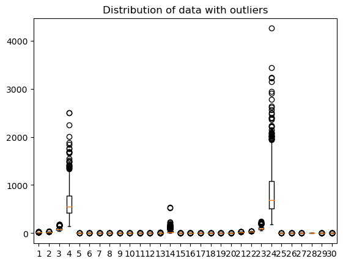

```python
plt.boxplot(X)
plt.title("Distribution of data with outliers")
```

In the graph above, the distribution of the data cannot be correctly appreciated. For this reason, we have to standarize features by removing the mean and scaling to unit variance using the StandardScaler function.

```python
# We create an instance of the class
miScaler = StandardScaler()

# We scale the data
X_scaled = miScaler.fit_transform(X)
```

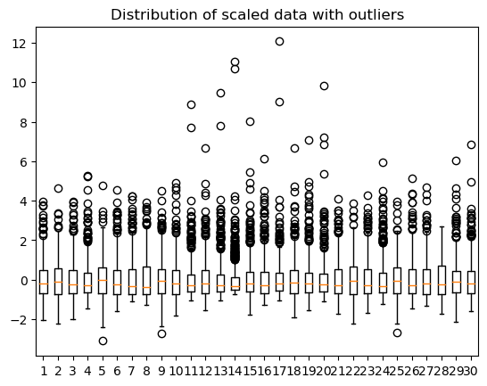

```python
plt.boxplot(X_scaled)
plt.title("Distribution of scaled data with outliers")
```

We can see a large number of examples that appear to be outliers, but the fact is that an outlier for one characteristic does not mean that it is for all characteristics. For that reason we have to do a study and see for how many features we consider an example to be an outlier.

#### Outliers detection

There are many techniques for detecting outliers, we are going to use the KNN anomaly detection.

In this method, we first define the number of nearest neighbors (k) and then we calculate the distance between each data point and its k-th nearest neighbor. Data points that have a large distance to their k-th nearest neighbor are considered outliers.

```python
# Define the number of nearest neighbors (k)
k = 5

# Calculate the distance to the k-th nearest neighbor for each data point
nbrs = NearestNeighbors(n_neighbors=k, algorithm='ball_tree').fit(X)
distances, indices = nbrs.kneighbors(X)

# Identify the rows with large distances to their k-th nearest neighbor as outliers
outliers = np.max(distances, axis=1) > np.percentile(np.max(distances, axis=1), q=95)
data_without_outliers = X

# Print the outliers
print("Outliers detected using k-NN method:")
for i, is_outlier in enumerate(outliers):
    if is_outlier:
        data_without_outliers = data_without_outliers.drop(i)
        print(f"Data example {i} is an outlier.")

num_outliers = np.sum(outliers)
```

```
Outliers detected using k-NN method:
Data example 0 is an outlier.
Data example 18 is an outlier.
Data example 23 is an outlier.
Data example 24 is an outlier.
Data example 56 is an outlier.
Data example 72 is an outlier.
Data example 82 is an outlier.
Data example 108 is an outlier.
Data example 122 is an outlier.
Data example 162 is an outlier.
Data example 164 is an outlier.
Data example 180 is an outlier.
Data example 202 is an outlier.
Data example 203 is an outlier.
Data example 212 is an outlier.
Data example 219 is an outlier.
Data example 236 is an outlier.
Data example 265 is an outlier.
Data example 272 is an outlier.
Data example 339 is an outlier.
Data example 352 is an outlier.
Data example 368 is an outlier.
Data example 369 is an outlier.
Data example 372 is an outlier.
Data example 417 is an outlier.
Data example 461 is an outlier.
Data example 503 is an outlier.
Data example 521 is an outlier.
Data example 564 is an outlier.
```

Now we are going to plot the average distances for each example in the dataset.

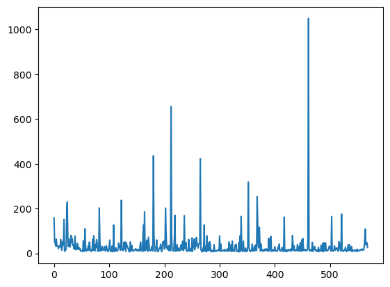

```python
plt.plot(distances.mean(axis=1))
```

As we can see, there are some spikes that indicate that these examples are potencially anomalies or outliers in the dataset.

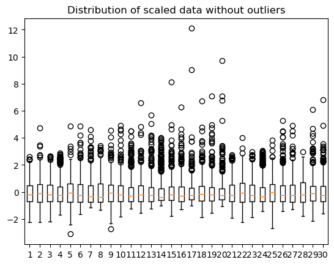

```python
miScaler_out = StandardScaler()
X_scaled_without = miScaler_out.fit_transform(data_without_outliers)

plt.boxplot(X_scaled_without)
plt.title("Distribution of scaled data without outliers")
```

#### 3) Repeat each of the experiments seen in class with the K-Nearest Neighbors model, providing arguments for each of the steps taken along the process, and commenting on the partial results obtained with the selected dataset. Please use as many performance metrics as needed to illustrate the particularities of the selected dataset (e.g. imbalanced classes).

### STRATIFIED DATA

The StratifiedShuffleSplit is a method from the scikit-learn library used for splitting a dataset into train and test sets. It splits the data into train and test sets while preserving the percentage of samples for each target class.

So we stratify the sample ensuring that we have the same proportion of classes in one set as in the other.

#### K-FOLDS

As we need to perform cross-validation, we would need to set n_splits to a value greater than 1 to generate multiple random splits of the data, so we set n_splits to 10, it means that the dataset will be split into 10 different training and testing sets.

We set random_state to 0 (int) to ensure that the same random splits will be generated each time the code is run with the same dataset and parameters.

Finally, we keep a test_size of 0.2 what means that 20% of the data will be used for testing and 80% of the data will be used for training. We think it is an appropiate percentage for the dataset size.

```python
# We set the following variables that we are going to use during the notebook
n_splits = 10
test_size = 0.2
test_size_red = 0.7
random_state = 0
```

```python
# In this step we obtain the Stratified and Non Stratified training and test samples to use during the notebook
# We use StratifiedShuffleSplit for stratified training and test samples and ShuffleSplit for not stratified ones

sss = StratifiedShuffleSplit(n_splits=n_splits,test_size=test_size, random_state=random_state)
ss = ShuffleSplit(n_splits=n_splits,test_size=test_size, random_state=random_state)

for i, (train_index, test_index) in enumerate(sss.split(X, y)):

    X_train_sss = X_scaled[train_index,:]
    y_train_sss = y[train_index]
    X_test_sss = X_scaled[test_index,:]
    y_test_sss = y[test_index]

for i, (train_index, test_index) in enumerate(ss.split(X, y)):

    X_train_ss = X_scaled[train_index,:]
    y_train_ss = y[train_index]
    X_test_ss = X_scaled[test_index,:]
    y_test_ss = y[test_index]

sss_red = StratifiedShuffleSplit(n_splits=n_splits,test_size=test_size_red, random_state=random_state)
ss_red = ShuffleSplit(n_splits=n_splits,test_size=test_size_red, random_state=random_state)

for i, (train_index, test_index) in enumerate(sss_red.split(X, y)):

    X_train_sss_red = X_scaled[train_index,:]
    y_train_sss_red = y[train_index]
    X_test_sss_red = X_scaled[test_index,:]
    y_test_sss_red = y[test_index]

for i, (train_index, test_index) in enumerate(ss_red.split(X, y)):

    X_train_ss_red = X_scaled[train_index,:]
    y_train_ss_red = y[train_index]
    X_test_ss_red = X_scaled[test_index,:]
    y_test_ss_red = y[test_index]
```

```python
def KNN_function(n_neighbors, weights, p, cv, stratify, Matrix):

    cv = cv

    if stratify == sss:
        X_train = X_train_sss
        y_train = y_train_sss
        X_test = X_test_sss
        y_test = y_test_sss
    elif stratify == ss:
        X_train = X_train_ss
        y_train = y_train_ss
        X_test = X_test_ss
        y_test = y_test_ss
    elif stratify == sss_red:
        X_train = X_train_sss_red
        y_train = y_train_sss_red
        X_test = X_test_sss_red
        y_test = y_test_sss_red
    else:
        X_train = X_train_ss_red
        y_train = y_train_ss_red
        X_test = X_test_ss_red
        y_test = y_test_ss_red

    miKNNC = KNeighborsClassifier()
    param_grid = {'n_neighbors':n_neighbors,'weights':weights,'p':p}
    miGSCV = GridSearchCV(estimator=miKNNC,param_grid=param_grid,scoring='accuracy',cv=cv)#, verbose = 2)
    miGSCV.fit(X_train,y_train)

    miMejorModeloKNNStr_bestEstimator = miGSCV.best_estimator_
    miMejorModeloKNNStr_params = miGSCV.best_params_

    miMejorModeloKNNStr_bestEstimator.fit(X_train,y_train)

    y_pred = miMejorModeloKNNStr_bestEstimator.predict(X_test)

    print("The best model is the one that contemplates the following parameters:\n", miMejorModeloKNNStr_params)
    print("The accuracy is:", round(100*sum(y_pred==y_test)/len(y_test),10), '%')
    print("The best score is:", miGSCV.best_score_)

    if Matrix == True:
        #Confusion matrix
        plt = plot_confusion_matrix(miMejorModeloKNNStr_bestEstimator,X_test, y_test)
        if cv == 5 and stratify == sss:
            plt.ax_.set_title("Confusion matrix, using stratification and K-Fold Cross-Validation")
        elif cv == 5 and stratify == ss:
            plt.ax_.set_title("Confusion matrix, without stratification and K-Fold Cross-Validation")
```

Now, we are going to test the KNN function for different parameters. Changing the number of neighbors and the weights to see the difference between them.

'Uniform' weights is a simple weighting scheme where all data points are given equal weight in a model.

'Distance' weights assigns different weights to data points based on their distance from the decision boundary. The closer a data point is to the boundary, the greater its weight in the model.

One important parameter in distance metrics is the value of 'p', which determines the type of distance metric used. Firstly, we have assigned 2 what means that we are using the Eucliden distance.

#### Neighbors = 9, Weights = 'uniform'

```python
KNN_9_Uniform = KNN_function([9], ['uniform'], [2], 5, sss, False)
```

```
The best model is the one that contemplates the following parameters:
 {'n_neighbors': 9, 'p': 2, 'weights': 'uniform'}
The accuracy is: 97.3684210526 %
The best score is: 0.956043956043956
```

#### Neighbors = 9, Weights = distance

```python
KNN_9_Distance = KNN_function([9], ['distance'], [2], 5, sss, False)
```

```
The best model is the one that contemplates the following parameters:
 {'n_neighbors': 9, 'p': 2, 'weights': 'distance'}
The accuracy is: 97.3684210526 %
The best score is: 0.956043956043956
```

#### Neighbors = 7, Weights = 'uniform'

```python
KNN_7_Uniform = KNN_function([7], ['uniform'], [2], 5, sss, False)
```

```
The best model is the one that contemplates the following parameters:
 {'n_neighbors': 7, 'p': 2, 'weights': 'uniform'}
The accuracy is: 97.3684210526 %
The best score is: 0.9648351648351647
```

#### Neighbors = 7, Weigths = distance

```python
KNN_7_Distance = KNN_function([7], ['distance'], [2], 5, sss, False)
```

```
The best model is the one that contemplates the following parameters:
 {'n_neighbors': 7, 'p': 2, 'weights': 'distance'}
The accuracy is: 97.3684210526 %
The best score is: 0.9648351648351647
```

#### Neighbors = 5, Weights = uniform

```python
KNN_5_Uniform = KNN_function([5], ['uniform'], [2], 5, sss, False)
```

```
The best model is the one that contemplates the following parameters:
 {'n_neighbors': 5, 'p': 2, 'weights': 'uniform'}
The accuracy is: 98.2456140351 %
The best score is: 0.9648351648351647
```

#### Neighbors = 5 Weights = distance

```python
KNN_5_Distance = KNN_function([5], ['distance'], [2], 5, sss, False)
```

```
The best model is the one that contemplates the following parameters:
 {'n_neighbors': 5, 'p': 2, 'weights': 'distance'}
The accuracy is: 98.2456140351 %
The best score is: 0.9648351648351647
```

#### Neighbors = 3 Weights = uniform

```python
KNN_3_Uniform = KNN_function([3], ['uniform'], [2], 5, sss, False)
```

```
The best model is the one that contemplates the following parameters:
 {'n_neighbors': 3, 'p': 2, 'weights': 'uniform'}
The accuracy is: 98.2456140351 %
The best score is: 0.964835164835165
```

#### Neighbors = 3 Weights = distance

```python
KNN_3_Distance = KNN_function([3], ['distance'], [2], 5, sss, False)
```

```
The best model is the one that contemplates the following parameters:
 {'n_neighbors': 3, 'p': 2, 'weights': 'distance'}
The accuracy is: 98.2456140351 %
The best score is: 0.964835164835165
```

#### Comments

| Neighbors/Weights | Accuracy | Score |
| --- | --- | --- |
| N = 9, W = 'uniform' | 97.3684210526 | 0.956043956043956 |
| N = 9, W = 'distance' | 97.3684210526 | 0.956043956043956 |
| N = 7, W = 'uniform' | 97.3684210526 | 0.9648351648351647 |
| N = 7, W = 'distance' | 97.3684210526 | 0.9648351648351647 |
| N = 5, W = 'uniform' | 98.2456140351 | 0.9648351648351647 |
| N = 5, W = 'distance' | 98.2456140351 | 0.9648351648351647 |
| **N = 3, W = 'uniform'** | **98.2456140351** | **0.964835164835165** |
| **N = 3, W = 'distance'** | **98.2456140351** | **0.964835164835165** |

After analyzing the results obtained, when fixing the number of neighbors and changing the weights, the same result is obtained. This is because it is a simple model where all the data is equally important, so it is not necessary to give it different weights. Therefore, we consider that using the 'uniform' weight is enough.

Regarding the results obtained with differents number of neighbors, we have the same results considering 3 and 5 neighbors. In general, increasing the number of neighbors used in a model can lead to a smoother decision boundary and reduce the impact of noise in the data. This lead us to a better performance and less overfitting. However, increasing the number of neighbors can also reduce the model's sensitivity to local patterns in the data, which may be important for some applications.

Therefore, to find the best estimation, we are going to perform a Grid Search taking into account different numbers of neighbors, weights and distances.

```python
KNN_GSCV = KNN_function([1,3,5,7,9,11,13],['uniform','distance'],[2,3,4,5], 5, sss, False)
```

```
The best model is the one that contemplates the following parameters:
 {'n_neighbors': 3, 'p': 2, 'weights': 'uniform'}
The accuracy is: 98.2456140351 %
The best score is: 0.964835164835165
```

Grid Search CV: Exhaustive search over specified parameter values for an estimator.

Using the gridSearch we obtain that the best model is the one that contemplates 3 neighbors, 'uniform' weights and a distance of 2 (Euclidean Distance). The Euclidean distance is the straight-line distance between two points in Euclidean space.

| Neighbors/Distance/Weights | Accuracy | Score |
| --- | --- | --- |
| N = 3, p = 2, W = 'uniform' | 98.2456140351 | 0.964835164835165 |

#### What about outliers? Shall we get better resultus without them? Lets see what happens.

```python
# Take off outliers from y
y_without_outliers = y

for i, is_outlier in enumerate(outliers):
    if is_outlier:
        y_without_outliers = y_without_outliers.drop(i)
```

```python
# Stratified training and test samples
sss_wo = StratifiedShuffleSplit(n_splits=n_splits,test_size=test_size, random_state=random_state)

for i, (train_index, test_index) in enumerate(sss_wo.split(X_scaled_without, y_without_outliers)):

    X_train_sss_wo = X_scaled_without[train_index,:]
    y_train_sss_wo  = y[train_index]
    X_test_sss_wo  = X_scaled_without[test_index,:]
    y_test_sss_wo = [test_index]
```

```python
KNN_GSCV2 = KNN_function([1,3,5,7,9,11,13],['uniform','distance'],[2,3,4,5], 5, sss_wo, False)
```

```
The best model is the one that contemplates the following parameters:
 {'n_neighbors': 3, 'p': 2, 'weights': 'uniform'}
The accuracy is: 94.2355889724 %
The best score is: 0.9647058823529411
```

#### Comments

| Dataset | Accuracy | Score |
| --- | --- | --- |
| **Original** | **98.2456140351** | **0.964835164835165** |
| Without outliers | 94.2355889724 | 0.9647058823529411 |

Analysing the results, we get worse results if we remove the "outliers" from our data set. So, taking this into account, we will keep them.

#### 4) Read the Scikit-learn library documentation and configure the automated validation script so that the GridSearchCV() function uses leave-one-out cross-validation instead of k-fold. Which conclusions can be drawn from the mean cross-validation scores and the test scores using a k-neighbor model with optimized k?

#### LEAVE ONE OUT

Leave-One-Out (LOO) is a cross-validation technique where the model is trained on all the samples in the dataset except one, which is left out for testing. This process is repeated for each sample in the dataset, so that each sample is used as a test set exactly once. The LOO technique is often used for small datasets, where there are only a few samples available for training and testing.

Now, we are going to test the KNN function using the LeaveOneOut() function.

```python
LOO_GSCV = KNN_function([1,3,5,7,9,11,13],['uniform','distance'],[2,3,4,5], LeaveOneOut(), sss, False)
```

```
The best model is the one that contemplates the following parameters:
 {'n_neighbors': 7, 'p': 2, 'weights': 'uniform'}
The accuracy is: 97.3684210526 %
The best score is: 0.9692307692307692
```

#### Comments

[output not shown]

With the results obtained for both K-Folds and LOO cases, we obtain a greater precision using K-Folds compared to LOO despite the fact that the score obtained for LOO is slightly higher than for cross validation, 0.9648 and 0.9692 respectively.

We notice that when running the grid search in both cases, CV is slightly faster than LOO, since it involves fewer iterations.

Likewise, due to the score result obtained, LOO is more reliable since it is a small dataset and uses all the data for training and testing.

#### 5) Elaborate on the need for stratifying the cross-validation process analyzing the distribution of samples by class. If so, please show with empirical evidence what could occur if such a stratification was not performed, specially when decreasing the number of samples of the dataset.

To analize the distribution of samples by class in the initial set, and in the train set, we do the following:

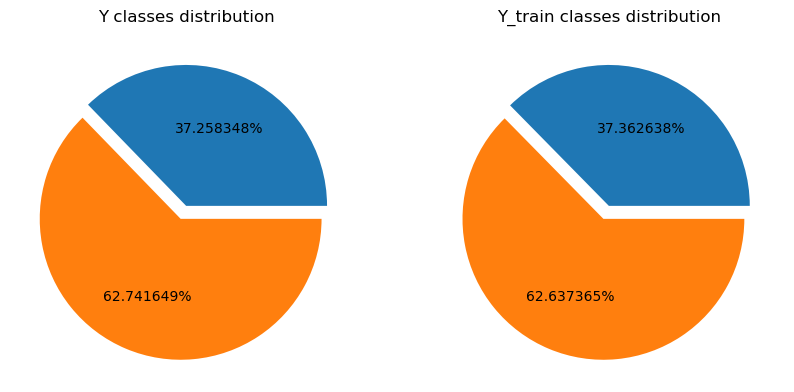

```python
# Count the number of cases per class
y_counter = Counter(y)

# Create two new variables for each of them
for k, v in y_counter.items():
    k = y_counter[0]
    v = y_counter[1]

# Do the same with the train sample
y_train_counter= Counter(y_train_sss)

for s, t in y_train_counter.items():
    s = y_train_counter[0]
    t = y_train_counter[1]

# Plot the values
fig, (ax1,ax2) = plt.subplots(1,2,figsize=(10,10))

y_values = k,v
ax1.pie(y_values, autopct='%.6f%%', explode=[0, 0.1])
ax1.set_title('Y classes distribution')

y_train_values = s,t
ax2.pie(y_train_values, autopct='%.6f%%', explode=[0, 0.1])
ax2.set_title('Y_train classes distribution')
```

```python
clases, ejemplos_clase = np.unique(y_train_sss, return_counts=True)
print("Number of examples per class in Y_train:")
for clase, cantidad in zip(clases, ejemplos_clase):
    print(f"Class {clase}: {cantidad}")
```

```
Number of examples per class in Y_train:
Class 0: 170
Class 1: 285
```

#### Comments

We can conclude that the distribution of classes is more or less the same in both cases using stratified data. This is because it divides the data into training and test sets preserving the percentage of samples for each target class.

#### Confusion Matrix

The best way to interpret the results is the confusion matrix, where we can explore which classes are worst classified and react accordingly. A confusion matrix is a table that summarises the performance of a classification model by comparing the predicted labels of the model with the actual labels in the data.

As we have seen before, using gridsearch the best model is the one with 3 neighbours, 'uniform' weights and a distance of 2, so let's plot its confusion matrix.

```
The best model is the one that contemplates the following parameters:
 {'n_neighbors': 3, 'p': 2, 'weights': 'uniform'}
The accuracy is: 98.2456140351 %
The best score is: 0.964835164835165
```

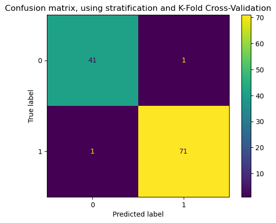

```python
KNN_function([3], ['uniform'], [2], 5, sss, True)
```

#### Comments

With stratified data and K-Folds we obtain a 96.48% score. In the confusion matrix we can see that 41 examples of class 0 are correctly classified while one example is classified as 1. Likewise, 71 examples of class 1 are correctly classified and 1 example of class 1 is classified as 0. Only 2 test samples are no classified properly.

### NON STRATIFIED DATA

The ShuffleSplit is a random permutation cross-validator so unlike other cross-validation strategies, random splits do not guarantee that all folds will be different, although this is still very likely for sizeable datasets.

Now we specify 'ss' (Non Stratified) in the stratify variable of the KNN_function.

```
The best model is the one that contemplates the following parameters:
 {'n_neighbors': 5, 'p': 2, 'weights': 'uniform'}
The accuracy is: 94.7368421053 %
The best score is: 0.9670329670329669
```

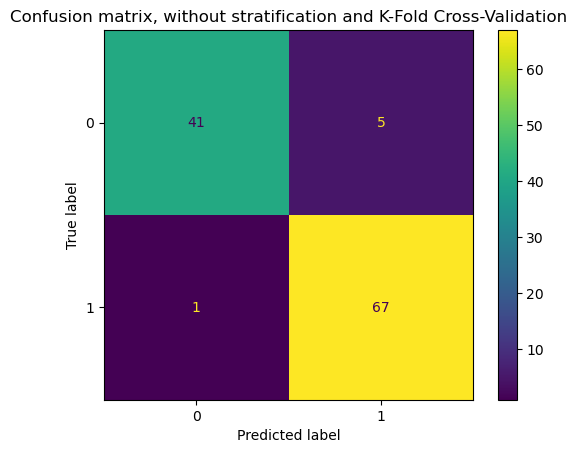

```python
KNN_function([1,3,5,7,9,11,13], ['uniform','distance'], [2,3,4,5], 5, ss, True)
```

Let's analize the distribution of samples in this case:

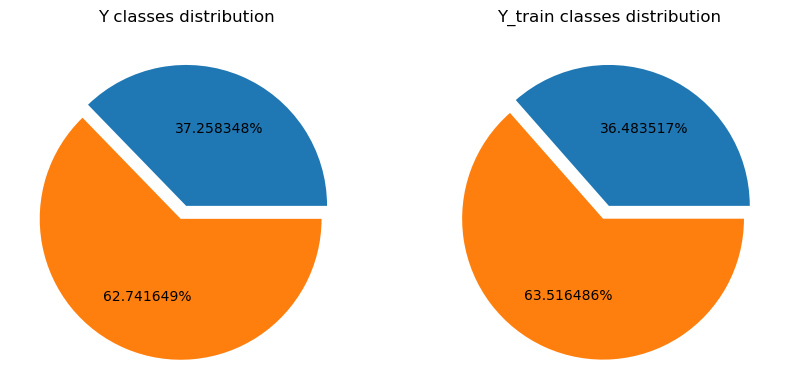

```python
y_train_counter= Counter(y_train_ss)

for s, t in y_train_counter.items():
    s = y_train_counter[0]
    t = y_train_counter[1]

fig, (ax1,ax2) = plt.subplots(1,2,figsize=(10,10))

y_values = k,v
ax1.pie(y_values, autopct='%.6f%%', explode=[0, 0.1])
ax1.set_title('Y classes distribution')

y_train_values = s,t
ax2.pie(y_train_values, autopct='%.6f%%', explode=[0, 0.1])
ax2.set_title('Y_train classes distribution')
```

```python
clases, ejemplos_clase = np.unique(y_train_ss, return_counts=True)
print("Number of examples per class in Y_train:")
for clase, cantidad in zip(clases, ejemplos_clase):
    print(f"Class {clase}: {cantidad}")
```

```
Number of examples per class in Y_train:
Class 0: 166
Class 1: 289
```

#### Results

| Train Sample | Accuracy | Score |
| --- | --- | --- |
| **Stratified** | **98.2456140351** | 0.964835164835165 |
| Non stratified | 94.7368421053 | **0.9670329670329669** |

### What happens when we reduce the dataset? And when we reduce the train sample?

```python
X_decreased = X[0:171]
y_decreased = y[0:171]

X_scaled_decreased = miScaler.fit_transform(X_decreased)

for i, (train_index, test_index) in enumerate(sss.split(X_decreased, y_decreased)):

    X_train_sss_dec= X_scaled_decreased[train_index,:]
    y_train_sss_dec = y[train_index]
    X_test_sss_dec = X_scaled_decreased[test_index,:]
    y_test_sss_dec = y[test_index]

for i, (train_index, test_index) in enumerate(ss.split(X_decreased, y_decreased)):

    X_train_ss_dec = X_scaled_decreased[train_index,:]
    y_train_ss_dec = y[train_index]
    X_test_ss_dec = X_scaled_decreased[test_index,:]
    y_test_ss_dec = y[test_index]
```

```python
def KNN_Reduced(n_neighbors, weights, p, cv, stratify, Matrix):

    if stratify == sss:
        X_train = X_train_sss_dec
        y_train = y_train_sss_dec
        X_test = X_test_sss_dec
        y_test = y_test_sss_dec
    else:
        X_train = X_train_ss_dec
        y_train = y_train_ss_dec
        X_test = X_test_ss_dec
        y_test = y_test_ss_dec

    miKNNC = KNeighborsClassifier()
    param_grid = {'n_neighbors':n_neighbors,'weights':weights,'p':p}
    miGSCV = GridSearchCV(estimator=miKNNC,param_grid=param_grid,scoring='accuracy',cv=5)#, verbose = 2)
    miGSCV.fit(X_train,y_train)

    miMejorModeloKNNNonStr_bestEstimator = miGSCV.best_estimator_
    miMejorModeloKNNNonStr_params = miGSCV.best_params_

    miMejorModeloKNNNonStr_bestEstimator.fit(X_train,y_train)

    y_pred = miMejorModeloKNNNonStr_bestEstimator.predict(X_test)


    print("The best model is the one that contemplates the following parameters:\n", miMejorModeloKNNNonStr_params)
    print("The accuracy is:", round(100*sum(y_pred==y_test)/len(y_test),10), '%')
    print("The best score is:", miGSCV.best_score_)

    if Matrix == True:
        #Confusion matrix
        plt = plot_confusion_matrix(miMejorModeloKNNNonStr_bestEstimator,X_test, y_test)
        if cv == 5 and stratify == sss:
            plt.ax_.set_title("Confusion matrix, using stratification and K-Fold Cross-Validation")
        elif cv == 5 and stratify == ss:
            plt.ax_.set_title("Confusion matrix, without stratification and K-Fold Cross-Validation")
```

```
The best model is the one that contemplates the following parameters:
 {'n_neighbors': 3, 'p': 5, 'weights': 'uniform'}
The accuracy is: 94.2857142857 %
The best score is: 0.962962962962963
```

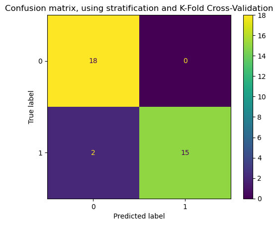

```python
KNN_Reduced([1,3,5,7,9,11,13], ['uniform','distance'], [2,3,4,5], 5, sss, True)
```

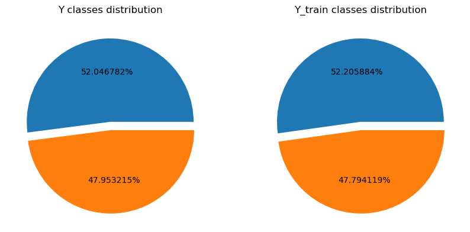

```python
y_decreased_counter = Counter(y_decreased)

for k, v in y_decreased_counter.items():
    k = y_decreased_counter[0]
    v = y_decreased_counter[1]

y_train_counter = Counter(y_train_sss_dec)

for s, t in y_train_counter.items():
    s = y_train_counter[0]
    t = y_train_counter[1]

fig, (ax1,ax2) = plt.subplots(1,2,figsize=(10,10))

y_decreased_values = k,v
ax1.pie(y_decreased_values, autopct='%.6f%%', explode=[0, 0.1])
ax1.set_title('Y classes distribution')

y_train_values = s,t
ax2.pie(y_train_values, autopct='%.6f%%', explode=[0, 0.1])
ax2.set_title('Y_train classes distribution')
```

```python
clases, ejemplos_clase = np.unique(y_train_sss_dec, return_counts=True)
print("Number of examples per class in Y_train:")
for clase, cantidad in zip(clases, ejemplos_clase):
    print(f"Class {clase}: {cantidad}")
```

```
Number of examples per class in Y_train:
Class 0: 71
Class 1: 65
```

#### Comments

```
The best model is the one that contemplates the following parameters:
 {'n_neighbors': 11, 'p': 3, 'weights': 'uniform'}
The accuracy is: 97.1428571429 %
The best score is: 0.9484126984126984
```

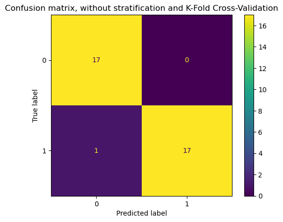

```python
KNN_Reduced([1,3,5,7,9,11,13], ['uniform','distance'], [2,3,4,5], 5, ss, True)
```

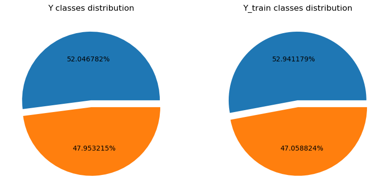

```python
y_train_counter = Counter(y_train_ss_dec)

for s, t in y_train_counter.items():
    s = y_train_counter[0]
    t = y_train_counter[1]

fig, (ax1,ax2) = plt.subplots(1,2,figsize=(10,10))

y_decreased_values = k,v
ax1.pie(y_decreased_values, autopct='%.6f%%', explode=[0, 0.1])
ax1.set_title('Y classes distribution')

y_train_values = s,t
ax2.pie(y_train_values, autopct='%.6f%%', explode=[0, 0.1])
ax2.set_title('Y_train classes distribution')
```

```python
clases, ejemplos_clase = np.unique(y_train_sss_dec, return_counts=True)
print("Number of examples per class in Y_train:")
for clase, cantidad in zip(clases, ejemplos_clase):
    print(f"Class {clase}: {cantidad}")
```

```
Number of examples per class in Y_train:
Class 0: 71
Class 1: 65
```

#### Will the results depends on the part of the data we take from the initial dataset?

```python
X_decreased = X[171:342]
y_decreased = y[171:342]

X_scaled_decreased = miScaler.fit_transform(X_decreased)

for i, (train_index, test_index) in enumerate(sss.split(X_decreased, y_decreased)):

    X_train_sss_dec= X_scaled_decreased[train_index,:]
    y_train_sss_dec = y[train_index]
    X_test_sss_dec = X_scaled_decreased[test_index,:]
    y_test_sss_dec = y[test_index]

for i, (train_index, test_index) in enumerate(ss.split(X_decreased, y_decreased)):

    X_train_ss_dec = X_scaled_decreased[train_index,:]
    y_train_ss_dec = y[train_index]
    X_test_ss_dec = X_scaled_decreased[test_index,:]
    y_test_ss_dec = y[test_index]
```

```
The best model is the one that contemplates the following parameters:
 {'n_neighbors': 7, 'p': 5, 'weights': 'uniform'}
The accuracy is: 60.0 %
The best score is: 0.5224867724867724
```

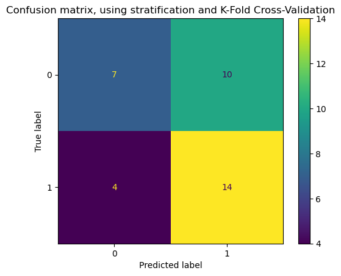

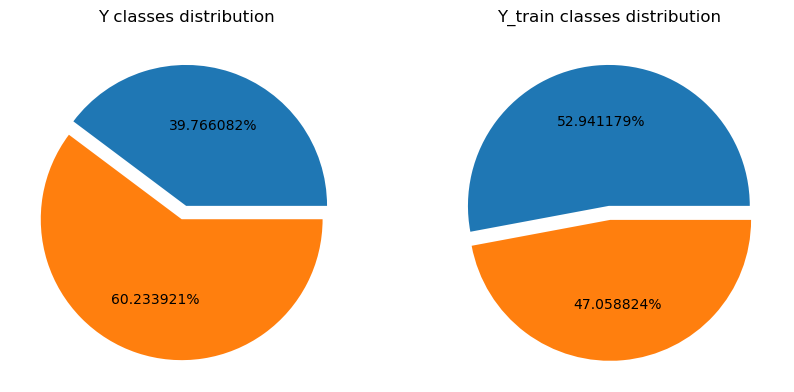

```python
KNN_Reduced([1,3,5,7,9,11,13], ['uniform','distance'], [2,3,4,5], 5, sss, True)

y_decreased_counter = Counter(y_decreased)

for k, v in y_decreased_counter.items():
    k = y_decreased_counter[0]
    v = y_decreased_counter[1]

y_train_counter = Counter(y_train_sss_dec)

for s, t in y_train_counter.items():
    s = y_train_counter[0]
    t = y_train_counter[1]

fig, (ax1,ax2) = plt.subplots(1,2,figsize=(10,10))

y_decreased_values = k,v
ax1.pie(y_decreased_values, autopct='%.6f%%', explode=[0, 0.1])
ax1.set_title('Y classes distribution')

y_train_values = s,t
ax2.pie(y_train_values, autopct='%.6f%%', explode=[0, 0.1])
ax2.set_title('Y_train classes distribution')
```

```python
clases, ejemplos_clase = np.unique(y_train_sss_dec, return_counts=True)
print("Number of examples per class in Y_train:")
for clase, cantidad in zip(clases, ejemplos_clase):
    print(f"Class {clase}: {cantidad}")
```

```
Number of examples per class in Y_train:
Class 0: 72
Class 1: 64
```

```
The best model is the one that contemplates the following parameters:
 {'n_neighbors': 13, 'p': 2, 'weights': 'uniform'}
The accuracy is: 40.0 %
The best score is: 0.558994708994709
```

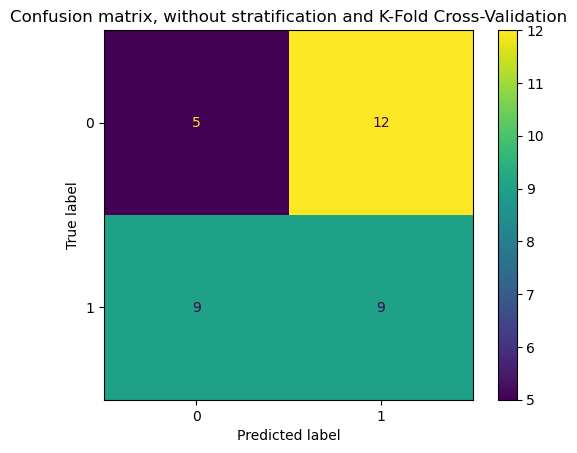

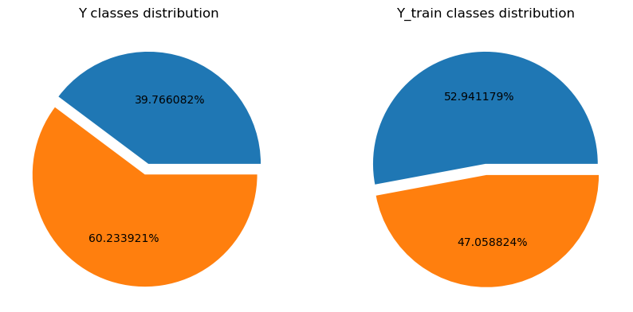

```python
KNN_Reduced([1,3,5,7,9,11,13], ['uniform','distance'], [2,3,4,5], 5, ss, True)

y_train_counter = Counter(y_train_ss_dec)

for s, t in y_train_counter.items():
    s = y_train_counter[0]
    t = y_train_counter[1]

fig, (ax1,ax2) = plt.subplots(1,2,figsize=(10,10))

ax1.pie(y_decreased_values, autopct='%.6f%%', explode=[0, 0.1])
ax1.set_title('Y classes distribution')

y_train_values = s,t
ax2.pie(y_train_values, autopct='%.6f%%', explode=[0, 0.1])
ax2.set_title('Y_train classes distribution')
```

```python
clases, ejemplos_clase = np.unique(y_train_ss_dec, return_counts=True)
print("Number of examples per class in Y_train:")
for clase, cantidad in zip(clases, ejemplos_clase):
    print(f"Class {clase}: {cantidad}")
```

```
Number of examples per class in Y_train:
Class 0: 72
Class 1: 64
```

```python
X_decreased = X[342:513]
y_decreased = y[342:513]
```

```
The best model is the one that contemplates the following parameters:
 {'n_neighbors': 7, 'p': 5, 'weights': 'uniform'}
The accuracy is: 60.0 %
The best score is: 0.5224867724867724
```

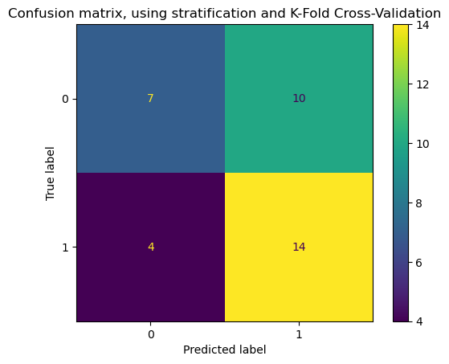

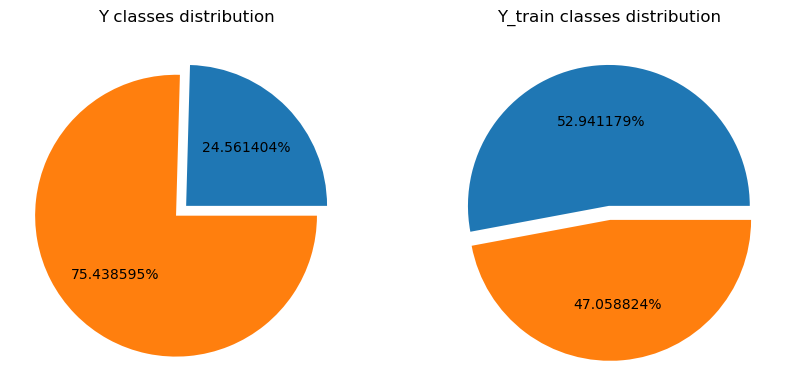

```python
KNN_Reduced([1,3,5,7,9,11,13], ['uniform','distance'], [2,3,4,5], 5, sss, True)

y_decreased_counter = Counter(y_decreased)

for k, v in y_decreased_counter.items():
    k = y_decreased_counter[0]
    v = y_decreased_counter[1]

y_train_counter = Counter(y_train_sss_dec)

for s, t in y_train_counter.items():
    s = y_train_counter[0]
    t = y_train_counter[1]

fig, (ax1,ax2) = plt.subplots(1,2,figsize=(10,10))

y_decreased_values = k,v
ax1.pie(y_decreased_values, autopct='%.6f%%', explode=[0, 0.1])
ax1.set_title('Y classes distribution')

y_train_values = s,t
ax2.pie(y_train_values, autopct='%.6f%%', explode=[0, 0.1])
ax2.set_title('Y_train classes distribution')
```

```python
clases, ejemplos_clase = np.unique(y_train_sss_dec, return_counts=True)
print("Number of examples per class in Y_train:")
for clase, cantidad in zip(clases, ejemplos_clase):
    print(f"Class {clase}: {cantidad}")
```

```
Number of examples per class in Y_train:
Class 0: 72
Class 1: 64
```

```
The best model is the one that contemplates the following parameters:
 {'n_neighbors': 13, 'p': 2, 'weights': 'uniform'}
The accuracy is: 40.0 %
The best score is: 0.558994708994709
```

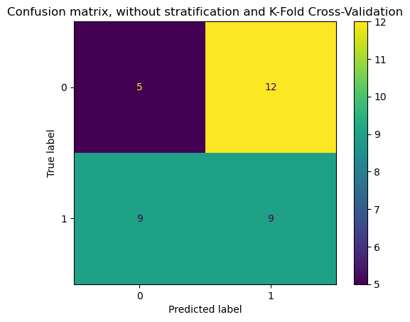

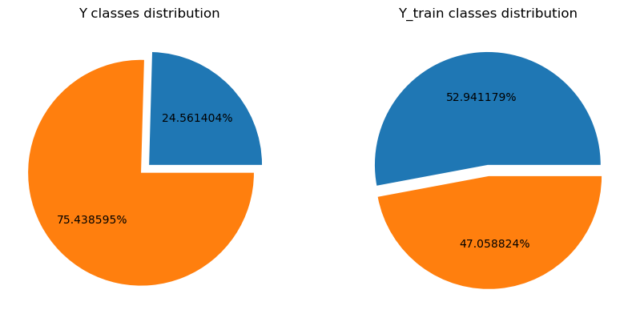

```python
KNN_Reduced([1,3,5,7,9,11,13], ['uniform','distance'], [2,3,4,5], 5, ss, True)

y_train_counter = Counter(y_train_ss_dec)

for s, t in y_train_counter.items():
    s = y_train_counter[0]
    t = y_train_counter[1]

fig, (ax1,ax2) = plt.subplots(1,2,figsize=(10,10))

ax1.pie(y_decreased_values, autopct='%.6f%%', explode=[0, 0.1])
ax1.set_title('Y classes distribution')

y_train_values = s,t
ax2.pie(y_train_values, autopct='%.6f%%', explode=[0, 0.1])
ax2.set_title('Y_train classes distribution')
```

```python
clases, ejemplos_clase = np.unique(y_train_sss_dec, return_counts=True)
print("Number of examples per class in Y_train:")
for clase, cantidad in zip(clases, ejemplos_clase):
    print(f"Class {clase}: {cantidad}")
```

```
Number of examples per class in Y_train:
Class 0: 72
Class 1: 64
```

#### Comments

| Dataset | Accuracy | Score |
| --- | --- | --- |
| **1st sample** |  |  |
| Stratified | 94.2857142857 | **0.962962962962963** |
| Non stratified | **97.1428571429** | 0.9484126984126984 |
| **2nd sample** |  |  |
| Stratified | **60** | 0.5224867724867724 |
| Non stratified | 40 | **0.558994708994709** |
| **3rd sample** |  |  |
| Stratified | **60** | 0.5224867724867724 |
| Non stratified | 40 | **0.558994708994709** |

Depending the part of the dataset, the results may vary. Only in the first sample we get a better result with non stratified data, but in the rest of the case using stratified data is the better option even though we can not mantain the same distribution of the data with such a poor dataset.

#### Reducing Training sample

In this step we increase the test size from 20% to 70%, thus reducing the size of the training data from 80% to 30%.

```
The best model is the one that contemplates the following parameters:
 {'n_neighbors': 5, 'p': 2, 'weights': 'uniform'}
The accuracy is: 96.4912280702 %
The best score is: 0.9647058823529411
```

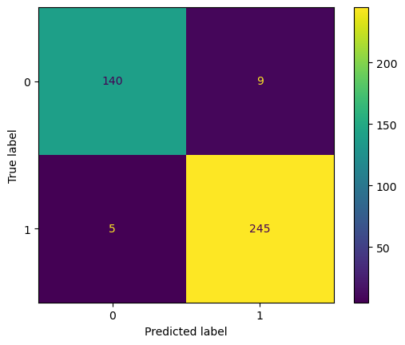

```python
KNN_function([1,3,5,7,9,11,13], ['uniform','distance'], [2,3,4,5], 5, sss_red, True)
```

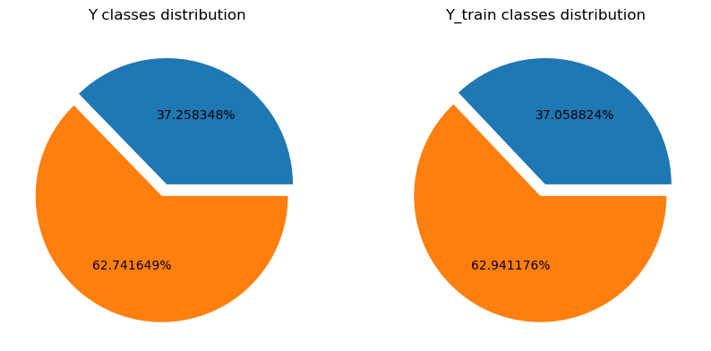

```python
y_counter = Counter(y)

for k, v in y_counter.items():
    k = y_counter[0]
    v = y_counter[1]

y_train_counter = Counter(y_train_sss_red)

for s, t in y_train_counter.items():
    s = y_train_counter[0]
    t = y_train_counter[1]

fig, (ax1,ax2) = plt.subplots(1,2,figsize=(10,10))

y_values = k,v
ax1.pie(y_values, autopct='%.6f%%', explode=[0, 0.1])
ax1.set_title('Y classes distribution')

y_train_values = s,t
ax2.pie(y_train_values, autopct='%.6f%%', explode=[0, 0.1])
ax2.set_title('Y_train classes distribution')
```

```python
clases, ejemplos_clase = np.unique(y_train_sss_red, return_counts=True)
print("Number of examples per class in Y_train:")
for clase, cantidad in zip(clases, ejemplos_clase):
    print(f"Class {clase}: {cantidad}")
```

```
Number of examples per class in Y_train:
Class 0: 63
Class 1: 107
```

#### Comments

We can see that for the stratified data the class distribution is similar to the initial set and the reduced one.

```
The best model is the one that contemplates the following parameters:
 {'n_neighbors': 3, 'p': 2, 'weights': 'uniform'}
The accuracy is: 94.2355889724 %
The best score is: 0.9647058823529411
```

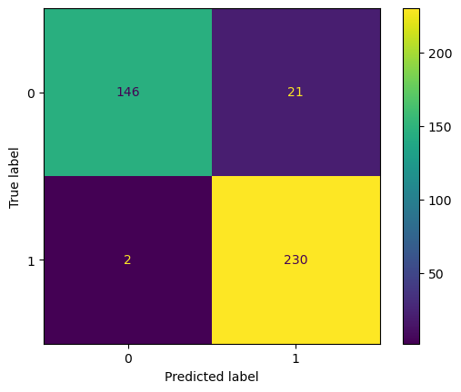

```python
KNN_function([1,3,5,7,9,11,13], ['uniform','distance'], [2,3,4,5], 5, ss_red, True)
```

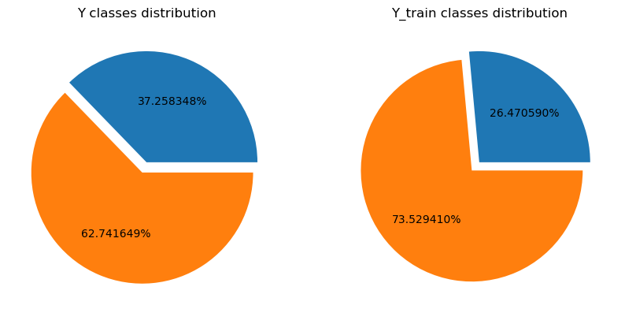

```python
y_train_counter= Counter(y_train_ss_red)

for s, t in y_train_counter.items():
    s = y_train_counter[0]
    t = y_train_counter[1]

fig, (ax1,ax2) = plt.subplots(1,2,figsize=(10,10))

y_values = k,v
ax1.pie(y_values, autopct='%.6f%%', explode=[0, 0.1])
ax1.set_title('Y classes distribution')

y_train_values = s,t
ax2.pie(y_train_values, autopct='%.6f%%', explode=[0, 0.1])
ax2.set_title('Y_train classes distribution')
```

```python
clases, ejemplos_clase = np.unique(y_train_ss_red, return_counts=True)
print("Number of examples per class:")
for clase, cantidad in zip(clases, ejemplos_clase):
    print(f"Class {clase}: {cantidad}")
```

```
Number of examples per class:
Class 0: 45
Class 1: 125
```

#### Comments

| Train sample reduce | Accuracy | Score |
| --- | --- | --- |
| Stratified | **96.4912280702** | 0.9647058823529411 |
| Non stratified | 94.2355889724 | 0.9647058823529411 |

We can see how for non stratified data the class distribution varies from the initial set to the reduced train sample. The accuracy of the model is lower than with stratified data.

From the results we can conclude that in the most of the cases we are goint to have better results if we use StratifiedShuffleSplit instead of ShuffleSplit

#### 7) Following the same approach as in the last section, enter the type of distance metric (“metric” parameter) within the cross-validation process. Evaluates the results and gains / losses of generalizability of the model.

During the exercise, grid searches have been carried out considering various metric parameters. In which it has always turned out that the weights with which the best result is obtained is for the 'uniform' one.